# Political Microtargeting

Safeguarding Democratic Values In Digital Political Practices

# Description

The Political Microtargeting Project is an interdisciplinary research effort focused on exploring the impact of political microtargeting on democratic processes and legitimacy.

Led by an experienced team of researchers from the Amsterdam School of Communication Research (ASCoR), the Institute for Information Law (IVIR), Amsterdam School for Cultural Analysis (ASCA), the project aims to make microtargeting practices visible, study their impact on citizens and society, and develop policy guidelines to analyze and limit their threats.

The project involves close collaboration with government agencies, non-academic partners, and other stakeholders to ensure that the research findings have a meaningful impact on society.

# Papers:

[Dobber, T., Kruikemeier, S., Helberger, N., & Goodman, E. (2023). **Shielding citizens? Understanding the impact of political advertisement transparency information.** *New Media & Society*, 0(0). https://doi.org/10.1177/14614448231157640](https://journals.sagepub.com/doi/pdf/10.1177/14614448231157640)

[Votta, F., Noroozian, A., Dobber, T., Helberger, N., & de Vreese, C. (2023). **Going Micro to Go Negative? Targeting Toxicity using Facebook and Instagram Ads.** *Computational Communication Research*, 5(1), 1-50.](https://www.aup-online.com/content/journals/10.5117/CCR2023.1.001.VOTT)

[van Drunen, M. Z., Groen-Reijman, E., Dobber, T., Noroozian, A., Leerssen, P. J., Helberger, N., de Vreese, C. H., & Votta, F. A. (2022). **Transparency and (no) more in the Political Advertising Regulation.** *Internet Policy Review*.](https://policyreview.info/articles/news/transparency-and-no-more-political-advertising-regulation/1616)

# Media Appearances / References

A list of media appearances and references in TV, radio and newspapers.

- [Research featured: ZDF Magazin Royale show about microtargeting during Germany 2021 election (in collab with Who Targets Me)](https://www.youtube.com/watch?v=8vq6MzGNZyM)

# Dashboards

Here is a list of dashboards that were created to monitor microtargeting and digital campaigns during election time:

- 🇳🇱 [2021 Dutch general election](https://favstats.github.io/DutchElectionObservatory/nl/index.html) (15th-17th March 2021)
- 🇩🇪 [2021 German general election](https://favstats.shinyapps.io/btw21_wtm/) (26th September 2021)
- 🇸🇪 [2022 Swedish general election](https://favstats.github.io/SwedishParliamentElection2023/) (11th September 2022)
- 🇺🇸 [2022 United States midterm elections](https://whotargetsme.shinyapps.io/midterms2022/) (8th November 2022)
- 🇺🇸 [2022 United States midterm elections - Georgia Runoff](https://whotargetsme.github.io/midterms2022_dashboard/) (6th December 2022)
- 🇮🇹 [2023 Lazio & Lombardy regional election](https://favstats.github.io/regionali2023/) (12-13th February 2023)
- 🇪🇪 [2023 Estonian parliamentary election](https://favstats.github.io/EstoniaElection2023/) (5th March 2023)
- 🇳🇱 [2023 Dutch provincial elections](https://favstats.github.io/ProvincialeStatenverkiezingen2023/) (15th March 2023)
- 🇲🇪 [2023 Montenegrin presidential elections](https://favstats.github.io/MontenegroPresidentialElection2023/) (19th March 2023)
- 🇦🇺 [2023 New South Wales state election](https://favstats.github.io/NSWAustralianElection2023/) (25th March 2023)

# Further Reading

- [Towards unfair political practices law: Learning lessons from the regulation of unfair commercial practices for online political advertising.](https://www.jipitec.eu/issues/jipitec-12-3-2021/5338)
- [Ad Delivery Algorithms: The Hidden Arbiters of Political Messaging](https://dl.acm.org/doi/10.1145/3437963.3441801)
- [Political advertising exposed: tracking Facebook ads in the 2021 Dutch elections](https://policyreview.info/articles/news/political-advertising-exposed-tracking-facebook-ads-2021-dutch-elections/1543)

# Team

###### Prof. dr. N. Helberger

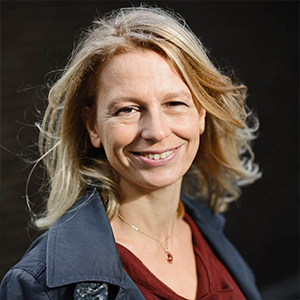

###### Prof. dr. C. de Vreese

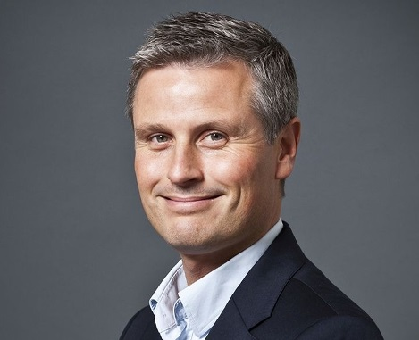

###### Prof. dr. B. Roessler

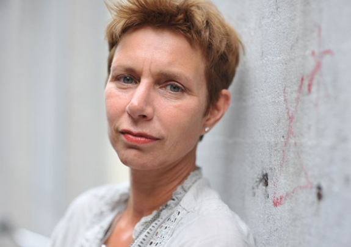

###### Prof. dr T. Dobber

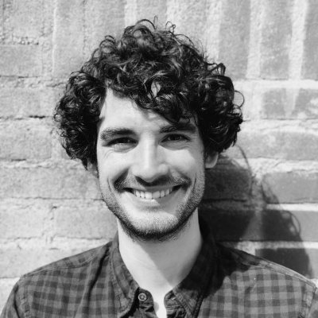

###### Dr. E. Groen-Reijman

[figure not shown]

###### Dr. M. van Drunen

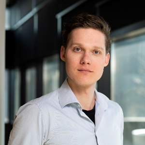

###### Dr. A. Noroozian

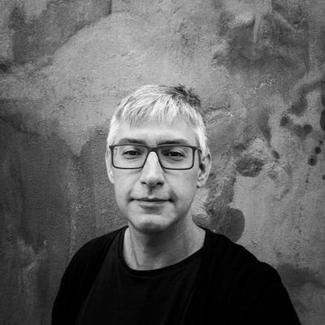

###### PhD candidate F. Votta

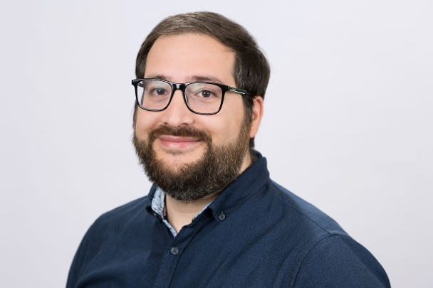